# Indice Reclutamiento D. trunculus

# ALTERNATIVAS DE CALCULO DEL INDICE DE RECLUTAMIENTO

## Porcentaje Individuos < 15 mm

Este es una forma mas simple calculando la proporción de ind bajo los 15 mm, en la zona y tiempo (AÑO y MES). Al ser proporcional, no importa el valor absoluto de individuos. Aca habría que identificar un nivel de referencia asociado a este porcentaje es necesario para caultelar la sustentabilidad del reclutamiento. Cargo data total de las estructuiras de tallas

```r
tallas13_24 <- readRDS("~/IEO/DATA/EDA_Donux_truculus_2023/tallas13_24.RDS")
```

Creo la función para estimar el `%`

```r
FUN <- function(x)  (sum(x) / length(x)) * 100

D15 <- tallas13_24 %>%
  filter(rastro=="POBLACIONAL") %>%
  group_by(ANO, MES, Sampling.point) %>%
  summarize(d15 = FUN(sizeE<15), rm.na=T)
```

representación con barPlot

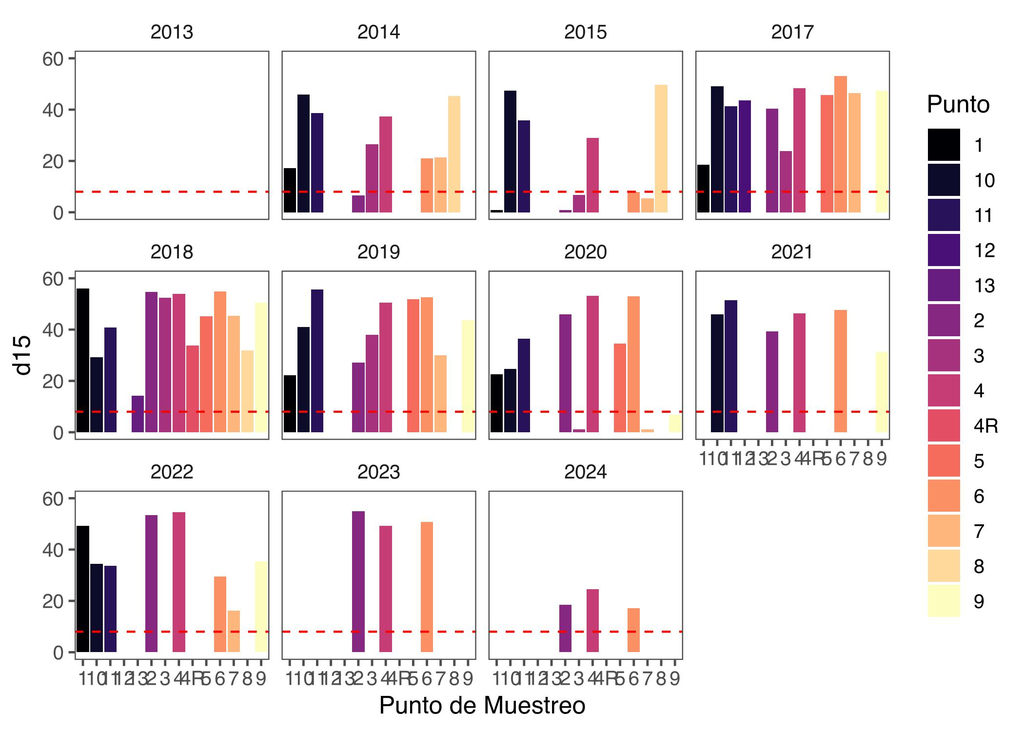

```r
D15plot <- ggplot(D15 %>%
                    drop_na(d15, Sampling.point),
                  aes(d15, Sampling.point,
                  fill=Sampling.point))+
  geom_col(position = "dodge")+
  scale_fill_viridis_d(option = "A",
                       name= "Punto")+
  facet_wrap(.~ANO)+
  geom_vline(xintercept = 8,
             col="red",
             linetype=2)+
  coord_flip()+
  theme_few()+
  xlim(0,60)+
  ylab("Punto de Muestreo")
D15plot
```

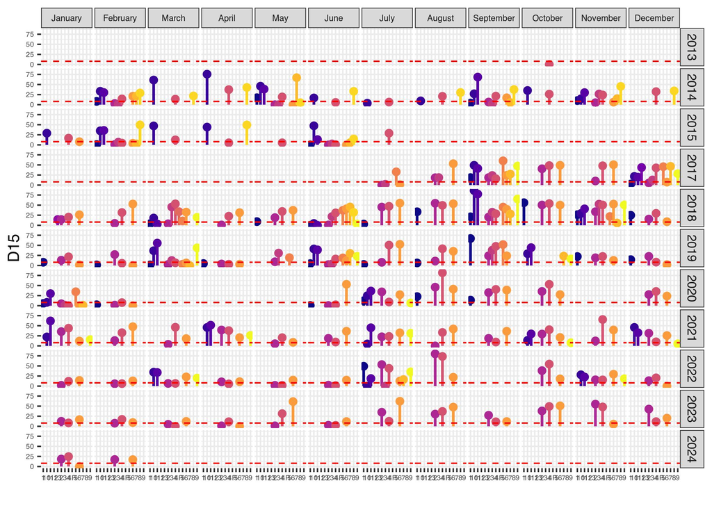

```r
landpop <- ggplot(D15 %>%
                    drop_na(d15, Sampling.point)) +
  geom_lollipop(aes(y=d15,
                  x=Sampling.point,
                  colour=Sampling.point),
              size=0.9)+
  scale_colour_viridis_d(option = "C",
                       name= "Punto")+
  geom_hline(yintercept = 8,
             col="red",
             linetype=2)+
  theme_bw() +
  theme(
    legend.position = "none",
    panel.border = element_blank(),
    panel.spacing = unit(0.1, "lines"),
    strip.text.x = element_text(size = 6),
    axis.text.x = element_text(size = 5),
    axis.text.y = element_text(size = 5)) +
  xlab("") +
  ylab("D15") +
  facet_grid(ANO~MES)
landpop
```

## Recruit Index size Based (from sea urchin, Chile)

Cálculo el índice

```r
indice_reclutamiento <- tallas13_24 %>%
  filter(sizeE<15,
         rastro=="POBLACIONAL") %>%
  group_by(ANO, MES, Sampling.point) %>%
  summarize(PROP = n() / nrow(tallas13_24)*100) %>%
  mutate(PROPLOG =log(PROP))
```

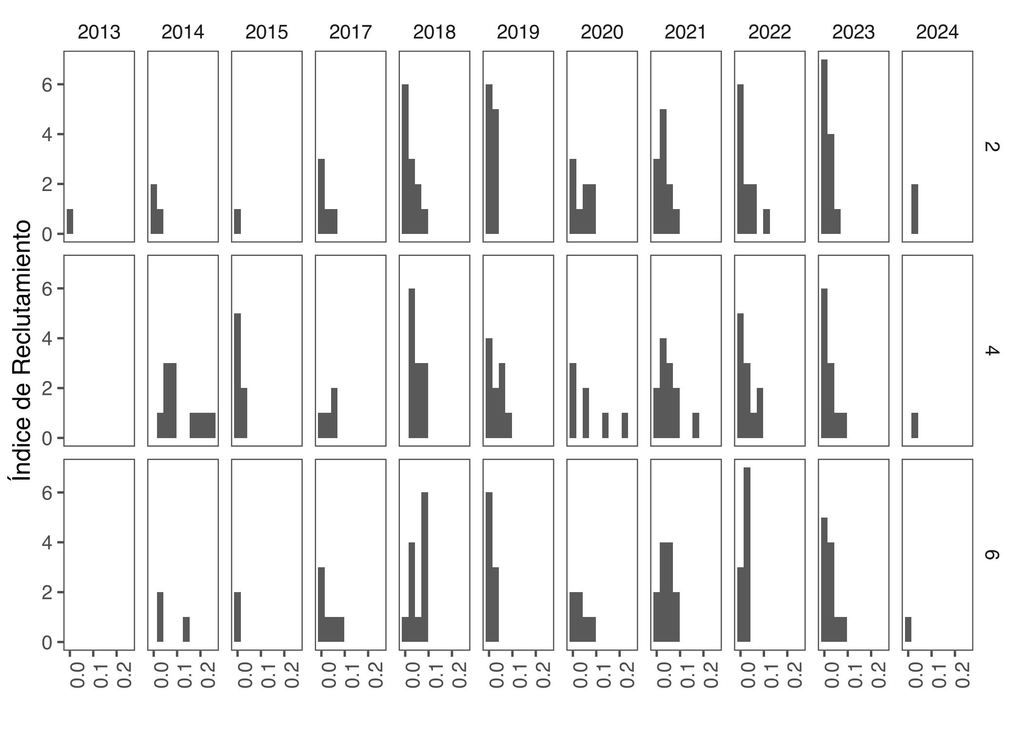

```r
indseg <- ggplot(indice_reclutamiento %>%
                   filter(Sampling.point %in% c(2, 4, 6)) %>%
                   drop_na(),
       aes(PROP)) +
  geom_histogram(bins = 10) +
  facet_grid(Sampling.point~ANO) +
  theme_few()+
    theme(axis.text.x = element_text(angle = 90, hjust = 1))+
   labs(x = "",
        y = "Índice de Reclutamiento")
indseg
```

Ahora estandarizo entre - y 1

```r
a <- -1  # Límite inferior del rango objetivo
b <- 1   # Límite superior del rango objetivo

# Calcular el valor mínimo y máximo de tus datos
min_x <- min(indice_reclutamiento$PROPLOG)
max_x <- max(indice_reclutamiento$PROPLOG)

# Aplicar la fórmula de normalización
indice_reclutamiento$PROPLOG2 <- ((indice_reclutamiento$PROPLOG- min_x) / (max_x - min_x)) * (b - a) + a
```

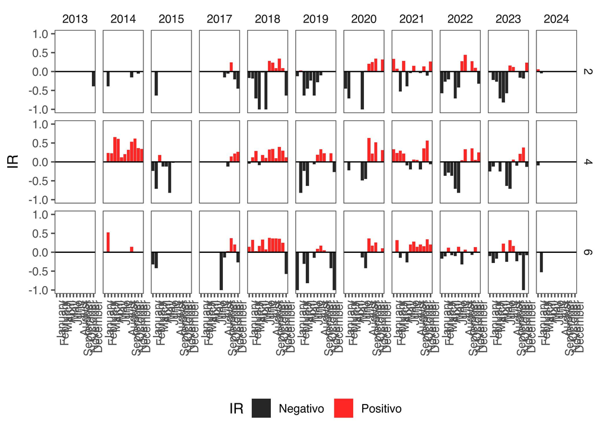

```r
indseg3 <- ggplot(indice_reclutamiento %>%
                filter(Sampling.point %in% c(2, 4, 6)) %>%
                  drop_na(),
       aes(x = factor(MES),
           y = PROPLOG2,
           fill=PROPLOG2 > 0)) +
  geom_bar(stat = "identity",
           alpha=0.85)  +
  scale_fill_manual(values = c("black", "red"),
                    labels = c("Negativo", "Positivo"),
                    name="IR") +
  #facet_wrap(.~ANO, ncol=10) +
  facet_grid(Sampling.point~ANO) +
  geom_hline(yintercept = 0, color = "black")+
  #scale_x_discrete(breaks = seq(from = 1996, to = 2022, by = 4))+
  theme_few()+
  theme(axis.text.x = element_text(angle = 90, hjust = 1),
        legend.position = "bottom")+
  labs(x = "",
        y = "IR")+
  ylim(-1,1)
indseg3
```

# INDICE DE DENSIDAD

Considerando los asuntos pendientes para la construccion de un indice poblacional desdee el 2013, extraeremos un un indice de densidad, por que es mas *ad-hoc* para los modelos de stock assessment (Caddy, 2004).

llamo los objetos con la base 2017-2020 y 2021- 2023, que serían `denspobtot2` y `D151720`. Identifico los valores a utilizar y uno bases.

```r
names(denspobtot2)
```

```
##  [1] "Date"                   "Beach"                  "Sampling.point"
##  [4] "m_track"                "tow_time"               "Latº"
##  [7] "Latmin"                 "Longº"                  "Longmin"
## [10] "Lat"                    "Long"                   "rastro"
## [13] "mariscador"             "SW"                     "SWsub"
## [16] "CSWsub"                 "MCSWsub"                "DCSWsub"
## [19] "Categoria"              "CAT"                    "Nmedida"
## [22] "Ndañossub"              "Tide_coef"              "Low_tide_hour"
## [25] "Catch_hour"             "species"                "Temp"
## [28] "ID_codificado_punto"    "ID_codificado_muestreo" "ANO"
## [31] "MES"                    "DIA"                    "fps"
## [34] "CSW"                    "fpm"                    "MCSW"
## [37] "DCSW"                   "TCSW"                   "Btotal"
## [40] "fpn"                    "NtotalCSW"              "Ndaños"
## [43] "Ntotal"                 "area"                   "bio"
## [46] "dens"
```

```r
names(D151720)
```

```
##  [1] "month...1"      "Sampling.point" "Talla media"    "sd"
##  [5] "Densidad"       "D15"            "month...7"      "Rendimiento"
##  [9] "...9"           "...10"          "DIA"            "MES"
## [13] "ANO"
```

```r
dens1720 <- D151720 %>%
  select(c(2, 12, 13, 5))

dens2123 <- denspobtot2 %>%
  select(c(3, 30, 31, 46)) %>%
  rename("Densidad"="dens") %>%
  as.data.frame()

dens2124 <- dens2123 %>%
  select(-c("Beach", "DIA"))


dens1724 <- rbind(dens1720,
                      dens2124)
```

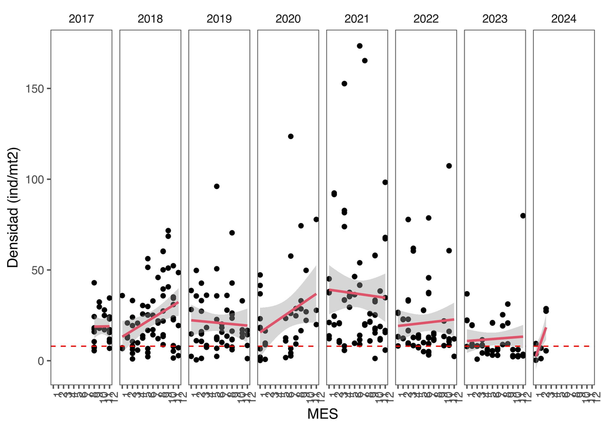

```r
plot_dens <- ggplot(dens1724 %>%
                      drop_na(),
                  aes(MES,Densidad))+
  geom_point()+
  geom_smooth(col=2,
              method = "lm")+
  facet_wrap(.~ANO, ncol=8)+
  scale_color_viridis_d(name="Sampling Points")+
  theme_few()+
  geom_hline(yintercept = 8,
             col="red",
             linetype=2)+
  theme(axis.text.x = element_text(angle = 90,
                                   hjust = 1))+
    scale_x_continuous(breaks = seq(from = 1,
                                  to = 12,
                                  by = 1,
                                  size=2))+
   labs(y="Densidad (ind/mt2)",
       x="MES")
plot_dens
```

ahora creo vector con desviación

```r
CV <- function(x) {
  sd_value <- sd(x, na.rm = TRUE)  # Calcular la desviación estándar, ignorando NA
  mean_value <- mean(x, na.rm = TRUE)  # Calcular la media, ignorando NA
  cv <- sd_value / mean_value
  # Calcular el coeficiente de variación
  return(cv)
}

vectordens <- dens1724 %>%
  group_by(ANO) %>%
  summarize(MEAND =mean(Densidad, na.rm=TRUE),
            SDD = sd(Densidad, na.rm = TRUE)/100,
            CV = CV(Densidad))


# escribo la salida
write_csv(vectordens, "DENSIDADPOBLACIONAL")
```

# REFERENCIAS

Caddy, J. F. (2004). Current usage of fisheries indicators and reference points , and their potential application to management of fisheries for marine invertebrates 1. *Canadian Journal of Fisheries & Aquatic Sciences*, *1324*(December 2002), 1307–1324. https://doi.org/10.1139/F04-132

Delgado, M., & Caparro, L. S. (2015). *ESTUDIO INTEGRAL EN ZONAS DE PROTECCIÓN PESQUERA Y MARISQUERA Y OTRAS ÁREAS MARINAS PROTEGIDAS DEL LITORAL ANDALUZ : APARTADO : ANÁLISIS Y SEGUIMIENTO DE LOS RECURSOS Y ACTIVIDADES PESQUERAS DE DEL LITORAL ANDALUZ*. Instituto Español Oceanográfico.

Delgado, M., & Silva, L. (2021). *NFORME TÉCNICO DE ASESORAMIENTO DEL ÁREA DE PESQUERÍAS DEL INSTITUTO ESPAÑOL DE OCEANOGRAFÍA (IEO, CSIC). Informe sobre la posibilidad de reducción de la veda de la coquina en el Golfo de Cádiz para la campaña 2021‐2022 Dirección*. IEO, Cadíz.

Delgado, M., & Silva, L. (2023). *INFORME TÉCNICO DE ASESORAMIENTO DEL ÁREA DE PESQUERÍAS DEL INSTITUTO ESPAÑOL DE OCEANOGRAFÍA (IEO, CSIC). Informe de asesoramiento para revisión de la veda de la coquina en el Golfo de Cádiz. Año 2023* (pp. 1–22). IEO, Cadiz.